# useR! 2018 Survey Stats

## Overview

283 of approximately 600 responded to the survey. This section summarises the overall demographics of the survey participants.

### by age

There were 283 participants in total. The following figure and table provide a breakdown by age categories.

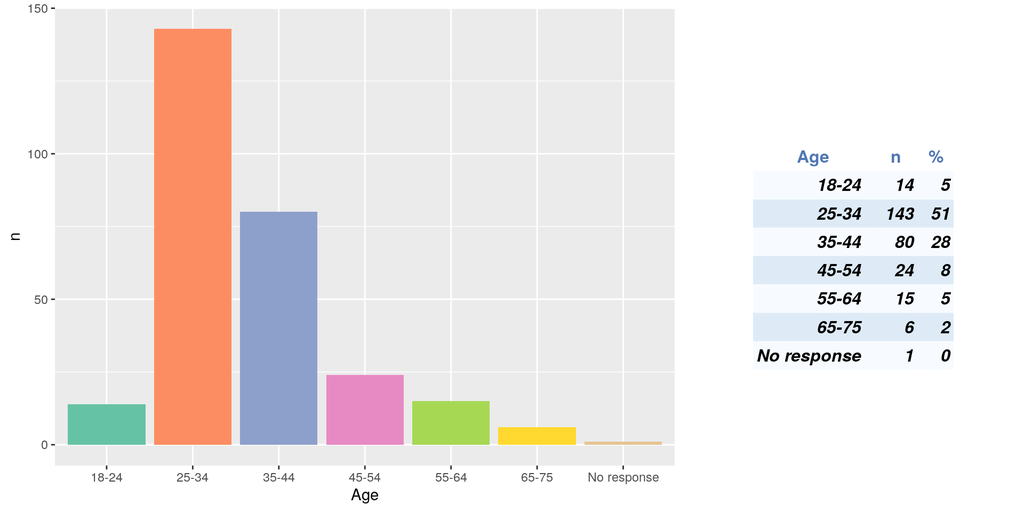

### by country

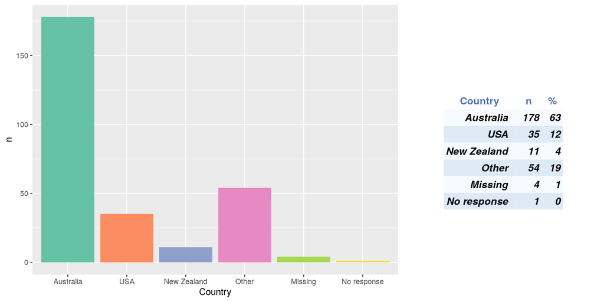

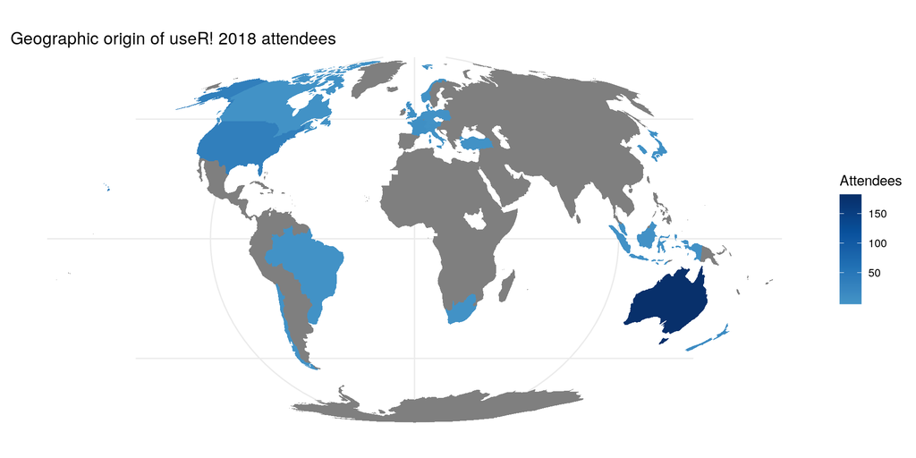

### by ethnicity

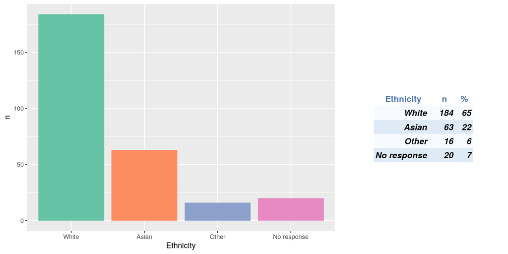

### by gender

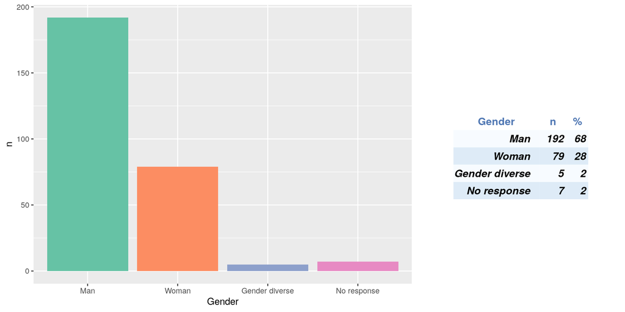

### by LGBT+ status

Question unintentionally omitted this year.

### by disability status

Other disabilities/impairments included a learning disability, a mobility impairment, and chronic pain. Some individuals specified more than one disability/impairment.

The option to specify “no disability” was not an explicit option on the form (unintentionally), hence the high non-response.

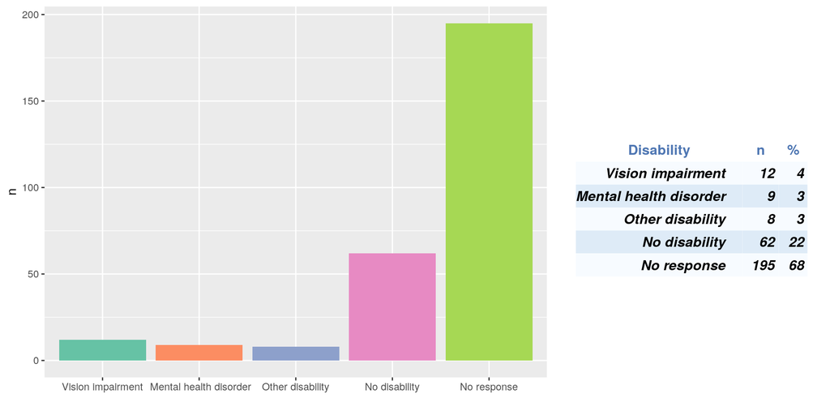

In an optional free text response, respondents highlighted the need for quiet space, chill-out space with seating and more tables during food breaks.

### by education

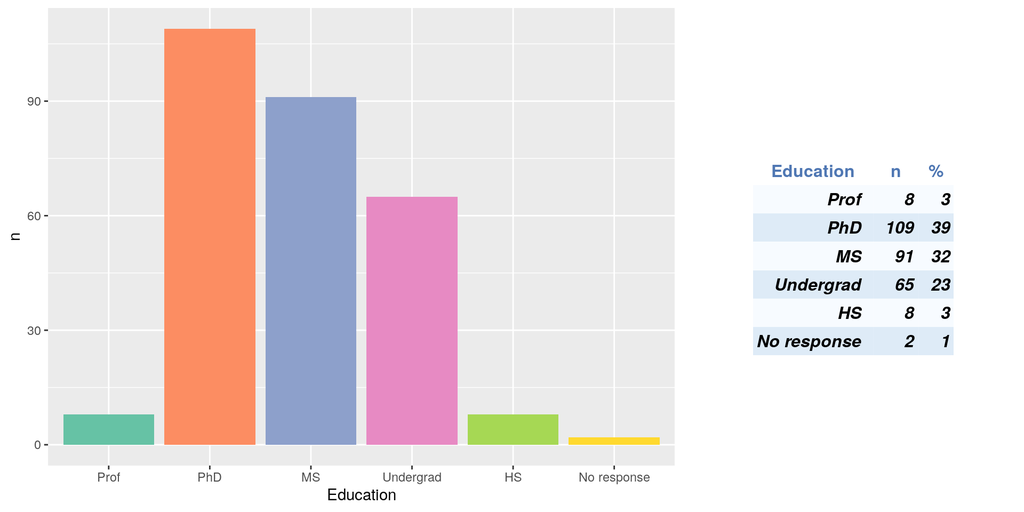

### by employment type

Here salaried students are categorised as employed in academia. Other includes retired, casually employed and unemployed.

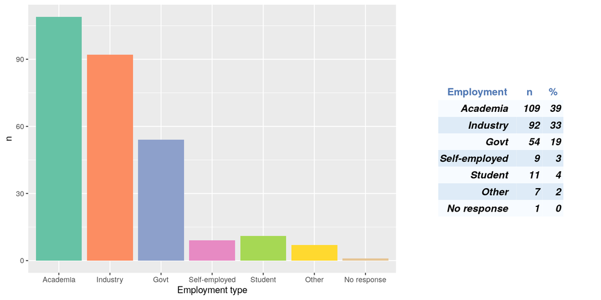

### by student status

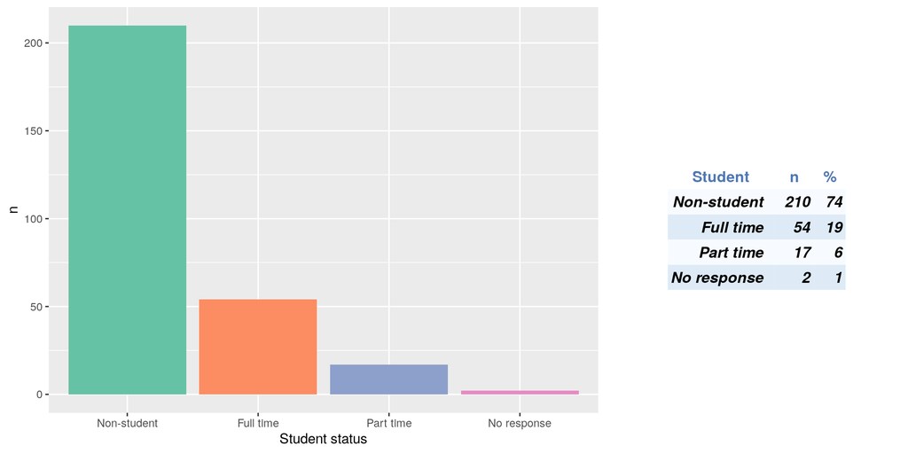

### by employment status

Employment here refers to any paid employment.

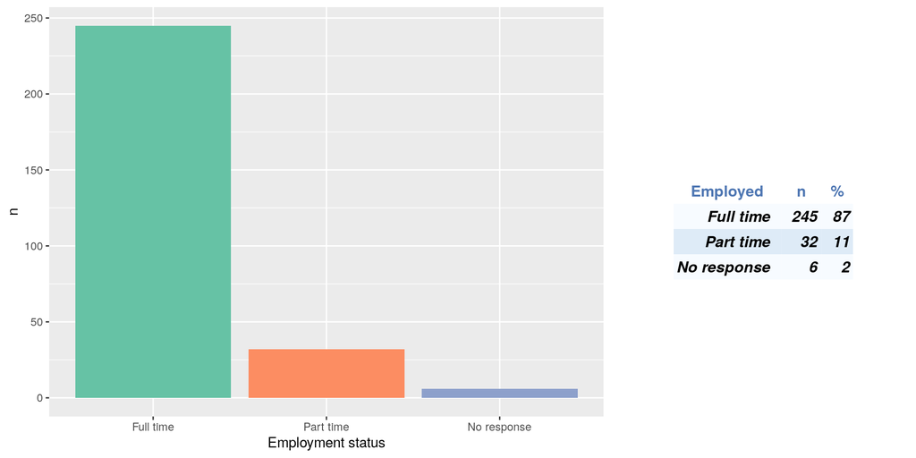

### by caregiver status

Here a caregiver is anyone that has dependents.

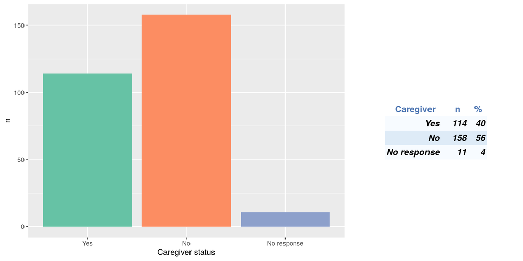

### by time using R

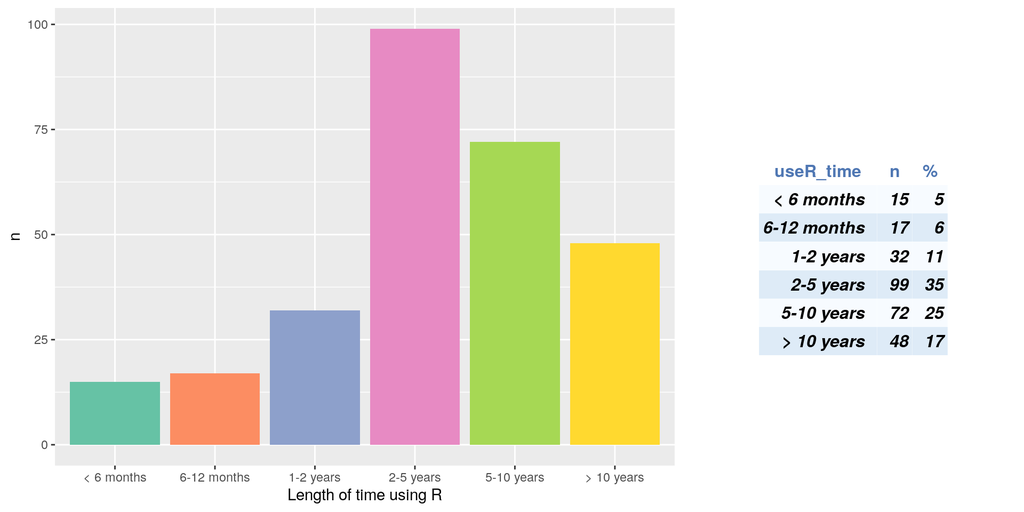

### by use of R for work

Here “fundamental” is used when the respondent said they used R for work; “supplemental” is used when the respondent said they use R when they can find an excuse to, but it’s not a requirement of their role.

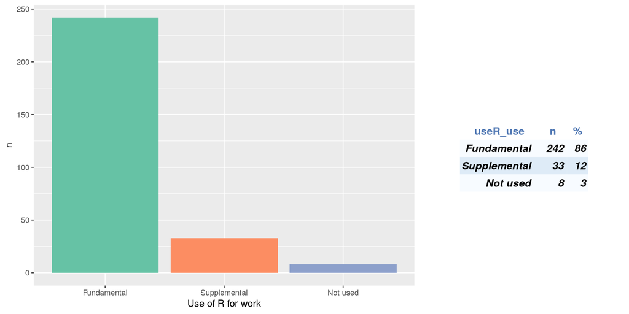

## Presentations

### by age

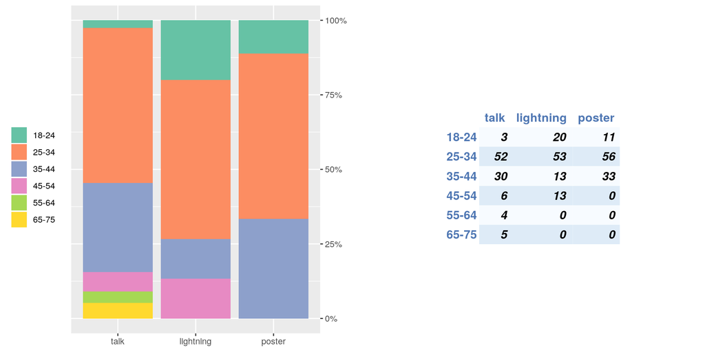

### by ethnicity

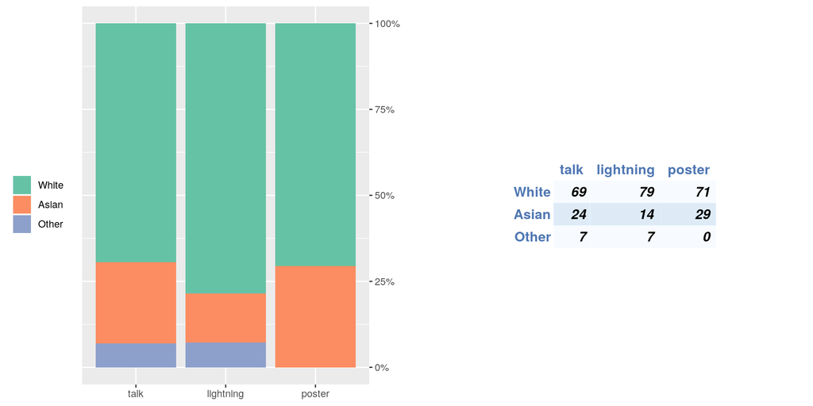

### by gender

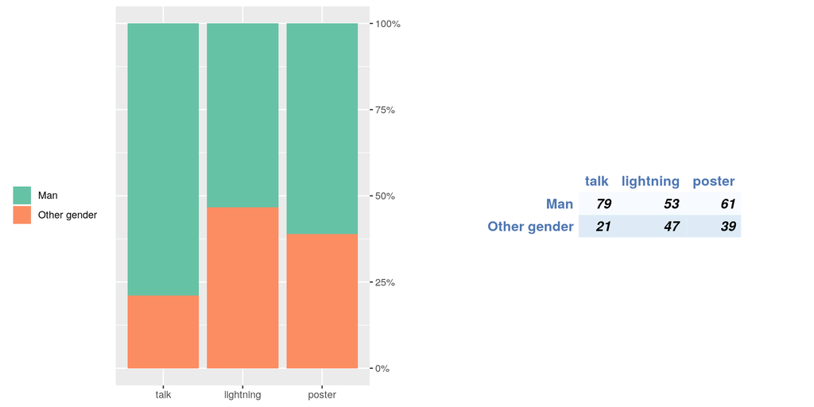

### by education

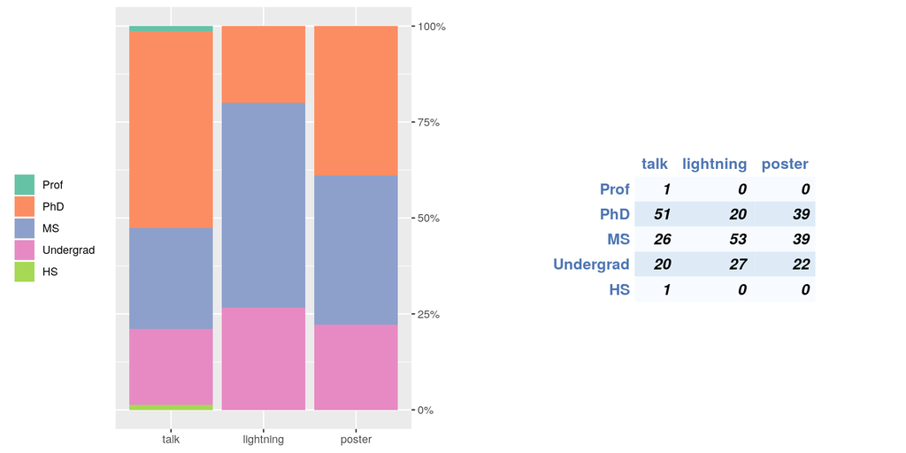

### by employment

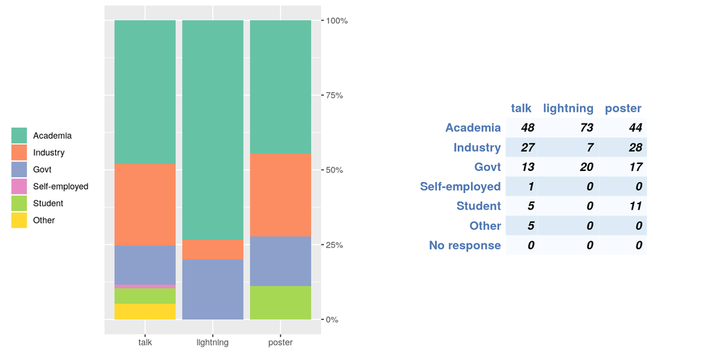

### by time using R

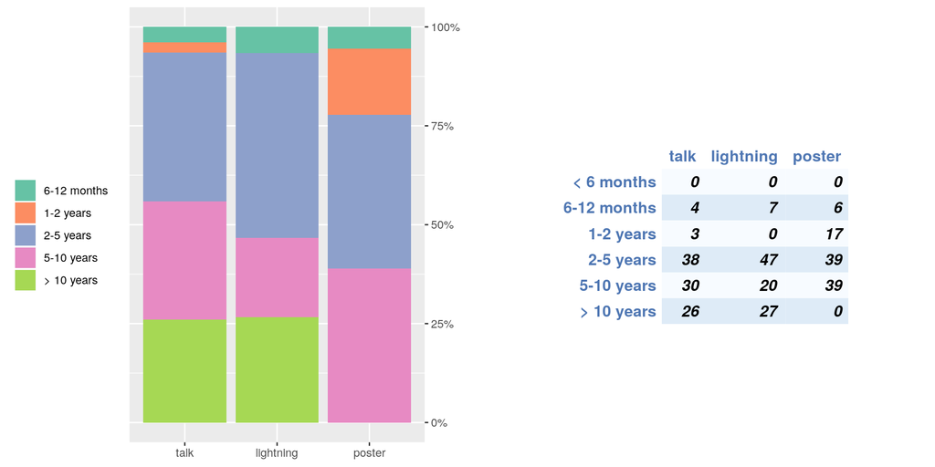

## Special Session

In total 55 people presentetd a speccial session.

### by age

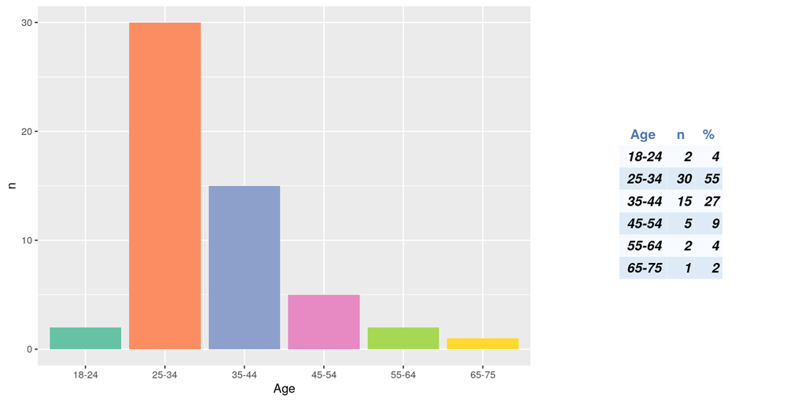

### by ethnicity

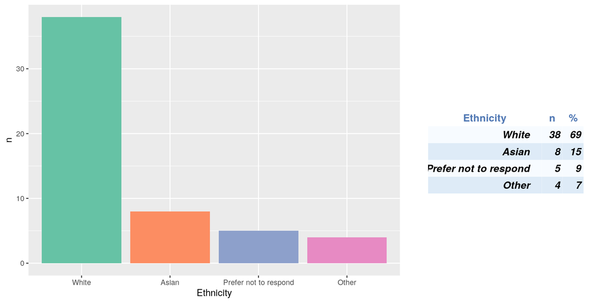

### by gender

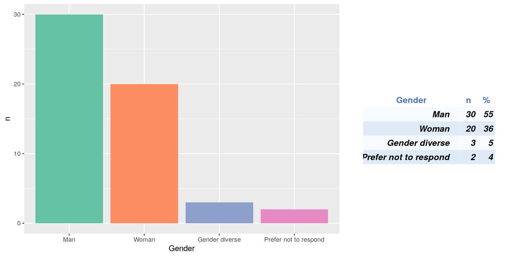

### by education

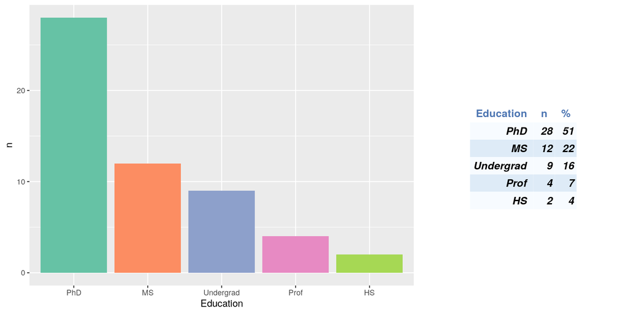

### by employment

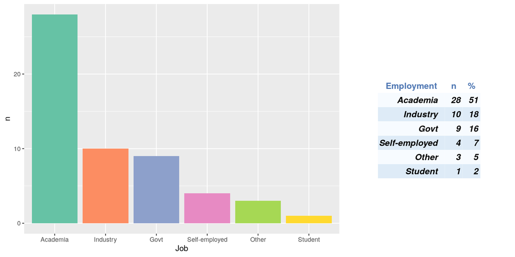

### by how long they’ve been using R

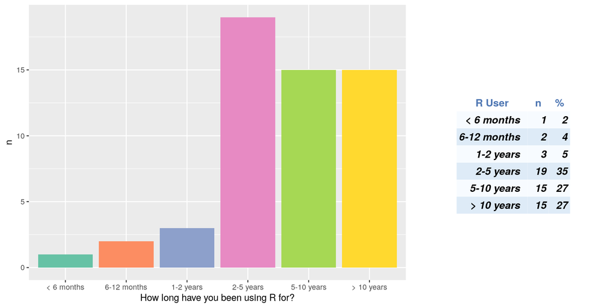

## Satisfaction with the Conference

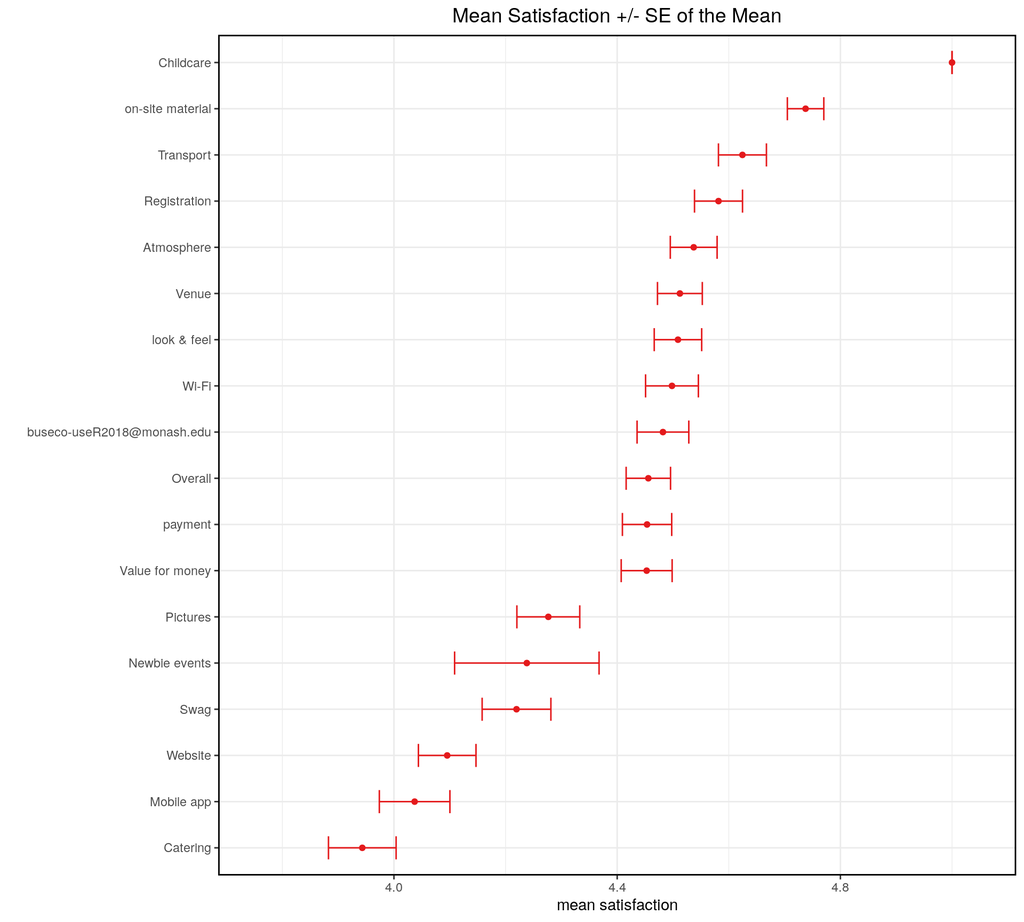